# Intervalos de Confianza

# Monitoria de Estadística

### Febrero de 2020

#### Profesor: Edwin Santiago Alférez

## 1. Introducción

Uno de los objetivos principales de la Estadística es el obtener información sobre parámetros desconocidos de una población a partir de una muestra aleatoria. La estimación intervalar es una de las formas más usadas para obtener esta información. Por ejemplo, si tenemos una población normal con media o varianza deconocida, o ambas, quizás no podemos conocer el valor exacto de estos parámetros a partir de un conjunto de datos, pero si podemos dar una idea de cómo serán estos parámetros. Los intervalos de confianza nos proporcionan un rango de valores sobre el cual el parámetro está incluido. Como este intervalo depende de la muestra usada, se garantiza que una significante proporción de los intervalos calculados contienen al valor real del parámetro. En esta sesión se utilizán métodos clásicos para la estimación intervalar de la media de una población. Además, se decribirán las funciones propias de R que sirven para calcular directamente este intervalo.

### 2. Intervalos de confianza

Para ilustrar el procedimiento para el cálculo de intervalos de confianza de la media poblacional, se utilizará un conjunto de datos de un grupo de estudiantes de estadística en una universidad australiana. Este conjunto de datos, llamado “survey” pertenece al package MASS que está incluido en la instalación básica de R pero debe cargarse con anterioridad de la siguiente manera:

```r
library(MASS) # Load the MASS package
```

Se puede visualizar los primeros datos de survey (es un dataframe) de la siguiente forma:

```r
head(survey)
```

|  | Sex | Wr.Hnd | NW.Hnd | W.Hnd | Fold | Pulse | Clap | Exer | Smoke | Height | M.I | Age |
| --- | --- | --- | --- | --- | --- | --- | --- | --- | --- | --- | --- | --- |
| 1 | Female | 18.5 | 18.0 | Right | R on L | 92 | Left | Some | Never | 173.00 | Metric | 18.250 |
| 2 | Male | 19.5 | 20.5 | Left | R on L | 104 | Left | None | Regul | 177.80 | Imperial | 17.583 |
| 3 | Male | 18.0 | 13.3 | Right | L on R | 87 | Neither | None | Occas | NA | NA | 16.917 |
| 4 | Male | 18.8 | 18.9 | Right | R on L | NA | Neither | None | Never | 160.00 | Metric | 20.333 |
| 5 | Male | 20.0 | 20.0 | Right | Neither | 35 | Right | Some | Never | 165.00 | Metric | 23.667 |
| 6 | Female | 18.0 | 17.7 | Right | L on R | 64 | Right | Some | Never | 172.72 | Imperial | 21.000 |

Para obtener más detalles del conjunto de datos del survey, se puede consultar la documentación de R.

#### 2.1 Estimación puntual de la media poblacional

Para cualquier muestra aleatoria podemos calcular siempre su media muestral. A pesar de que normalmente esta media no tiene el mismo valor de la media de la población actual, sirve como una buena estimación puntual. Por ejemplo, a partir del conjunto de datos “survey”, que es una muestra de la población estudiantil, podemos calcular su media muestral y usarla como una estimación del correspondiente parámetro de la población (media poblacional). Usando los datos cargados, una estimación puntual de la media de todos los estudiantes está dada por:

```r
mean(survey$Height, na.rm = TRUE) # skip missing value
```

```
## [1] 172.3809
```

Como algunos de los estudiantes encuestados no contestaron todas las preguntas, existen algunas variables con parámetros faltantes, por lo tanto, debemos filtrar estos valores anexando la opción `na.rm` con el argumento *TRUE* a la función `mean`.

#### 2.2. Estimaciòn intervalar de la media de una población con varianza conocida

Después de encontrar una estimación puntual de la media poblacional, necesitaremos un modo de cuantificar su precisión. Aquí discutimos el caso en que la varianza poblacional $\sigma^2$ se asume conocida. Denotamos el $100 \left(1-\frac{\alpha}{2} \right)$ percentil de la distribución normal estándar como $z_{\alpha/2}$ . Para cualquier muestra aleatoria, los 2 puntos finales del intervalo estimado con un nivel de confianza de $(1-\alpha) \%$ están dados por:
$$\bar{x} \pm z_{\alpha/2}\frac{\sigma}{\sqrt{n}}$$
En el ejemplo, asumimos que la desviación estándar $\sigma$ de la altura de todos los estudiantes es 9.48 cm (desviación poblacional). Para encontrar el margen del error y una estimación intervalar con un nivel de confianza del 95%, primero filtramos los valores que faltan en `survey$Height` con la función `na.omit`, y lo guardamos en `height.response`:

```r
height.response = na.omit(survey$Height)
```

A continuación se calcula el error estándar (desviación estándar de la media muestral):

```r
n = length(height.response)
sigma = 9.48
SE = sigma/sqrt(n); SE
```

```
## [1] 0.6557453
```

Debido a que el intervalo está centrado en $\bar{x}$, el 95% de confianza implica el 97.5th percentil de la distribución normal en la cola superior. Por lo tanto, $z_{\alpha/2}$ está dado por `qnorm(0.975)`. Lo multiplicamos por el error estándar SE y obtenemos el margen de error.

```r
E = qnorm(0.975)*SE; E
```

```
## [1] 1.285237
```

Finalmente, a la media muestral le sumamos y le restamos este valor para obtener los extremos del intervalo.

```r
xbar = mean(height.response)
IC = xbar + c(-E,E); IC
```

```
## [1] 171.0956 173.6661
```

**Conclusión**: Asumiendo la desviación estándar poblacional $\sigma$ como 9.48, el margen de error para la media de la altura de los estudiantes con 95% de confianza es 1.2852 centímetros, y el intervalo para la media poblacional es entre 171.10 y 173.67 centímetros.

**TIP**

Para representar gráficamente el intervalo de confianza para la media poblacional, se puede ejecutar el siguiente código:

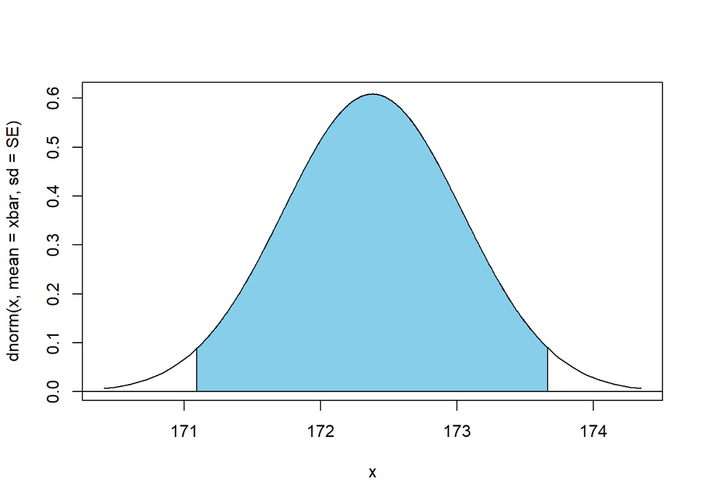

```r
# Gráfica de la función de densidad de la media muestral
curve(dnorm(x,mean=xbar,sd=SE),from=xbar-3*SE, to=xbar+3*SE)

# Gráfica de la región del intervalo
cord.x=c(IC[1],seq(IC[1],IC[2],0.01),IC[2])
cord.y=c(0,dnorm(seq(IC[1],IC[2],0.01),mean=xbar,sd=SE),0)
polygon(cord.x,cord.y,col="skyblue")
abline(h=0)
```

Hasta el momento hemos usado la fórmula general para el cálculo del intervalo de confianza, sin embargo, podemos aplicar la función `z.test` del paquete “TeachingDemos”. No es un paquete que se instala por defecto en R, este debe ser instalado y cargado previamente:

```r
library(TeachingDemos) # load TeachingDemos package
IC = z.test(height.response, sd=sigma, conf.level=0.95); IC
```

```
##
##  One Sample z-test
##
## data:  height.response
## z = 262.88, n = 209.00000, Std. Dev. = 9.48000, Std. Dev. of the
## sample mean = 0.65575, p-value < 2.2e-16
## alternative hypothesis: true mean is not equal to 0
## 95 percent confidence interval:
##  171.0956 173.6661
## sample estimates:
## mean of height.response
##                172.3809
```

#### 2.3 Estimación intervalar de la media de una población con varianza desconocida a partir de una muestra pequeña

Por otro lado, si la varianza poblacional $\sigma^2$ se asume como desconocida, para una muestra aleatoria pequeña, los puntos finales del intervalo estimado con nivel de confianza de $(1-\alpha) \%$ están dados por: $\bar{x}\pm t_{\alpha/2}\frac{s}{\sqrt{n}}$, donde $t_{\alpha/2}$ es el percentil $100(1-\alpha/2)$ de la distribución t-student con $n - 1$ grados de libertad y $s$ es la desviación estándar de la muestra. En el ejemplo dado, para encontrar el error marginal y el intervalo estimado al 95% de confianza utilizando únicamente los 10 primeros elementos de la muestra, primero hemos de filtrar los valores que faltan en `survey$Height` con la función `na.omit`, y guardarlo en `height.response`.

```r
height.response = na.omit(survey$Height)
height.response = height.response[1:10]
```

Entonces calculamos el error estándar estimado ya que la deviación de la población $\sigma$ es desconocida y se estima a partir de la desviación de la muestra $s$.

```r
n = length(height.response)
s = sd(height.response)
SE = s/sqrt(n); SE
```

```
## [1] 2.874441
```

De la misma manera que el caso anterior, hay dos colas de la distribución t-student, por lo tanto, el 95 de nivel de confianza implica el 97.5th percentil de la distribución t-student en la cola superior. De esta manera, $t_{}\alpha/2$ está dado por `qt(0.975,df=n-1)`. Lo multiplicamos por el error estándar estimado $SE$ y obtendremos el margen del error.

```r
E = qt(.975, df=n-1)*SE; E
```

```
## [1] 6.502436
```

A continuación se lo restamos y sumamos a la media muestral para determinar los límites del intervalo de confianza.

```r
xbar = mean(height.response)
IC = xbar + c(-E,E); IC
```

```
## [1] 162.1576 175.1624
```

**Conclusión**: Sin asumir la desviación estándar poblacional $\sigma$, el margen del error para la media de la altura de los estudiantes con 95% de confianza es de 6.502 centímetros y el intervalo de confianza para la media de la población está entre 162.16 y 175.16 centímetros.

**TIP**

Para representar gráficamente el intervalo de confianza para la media poblacional, se puede ejecutar el siguiente código:

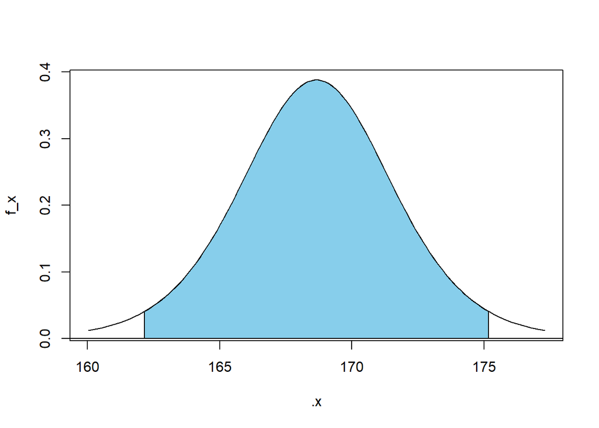

```r
.x = seq(xbar-3*SE,xbar+3*SE,length=100)
f_x = dt(seq(-3,3,length=100),df=n-1)
plot(.x,f_x,type="l")
cord.x=c(IC[1],seq(IC[1],IC[2],length=100),IC[2])
cord.y=c(0,dt(seq((IC[1]-xbar)/SE,(IC[2]-xbar)/SE,length=100),df=n-1),0)
polygon(cord.x,cord.y,col="skyblue")
abline(h=0)
```

De igual forma, R contiene una función que calcula este intervalo directamente. La función se denomina `t.test` y pertenece al paquete “stats” que normalmente está integrado en la instalación básica de R.

```r
t.test(height.response)
```

```
##
##  One Sample t-test
##
## data:  height.response
## t = 58.676, df = 9, p-value = 6.111e-13
## alternative hypothesis: true mean is not equal to 0
## 95 percent confidence interval:
##  162.1576 175.1624
## sample estimates:
## mean of x
##    168.66
```

#### 2.4 Estimación intervalar de la media de una población con varianza desconocida a partir de una muestra grande

Ya que la distribución t-student con un grado de libertad alto (n > 30) se puede considerar aproximadamente igual a una distribución normal, si la varianza poblacional $\sigma^2$ es desconocida, para una muestra de tamaño suficiente, los puntos finales del intervalo estimado con un nivel de confianza (1 - $\alpha$) % están dados por:
$$\bar{x} \pm z_{\alpha/2}\frac{s}{\sqrt{n}}$$
, donde $z_{\alpha/2}$ es el percentil $100(1-\alpha/2)$ de la distribución normal y $s$ es la desviación estándar de la muestra. En el ejemplo dado, al no conocer la desviación estándar poblacional $\sigma$ de la altura de los estudiantes, para encontrar el margen de error y el intervalo de confianza estimado con 95% de confianza, primero debemos filtrar los valores que faltan en `survey$Height` con la función `na.omit`,y guardarlo en `height.response`.

```r
height.response = na.omit(survey$Height)
```

Después calculamos el error estándar estimado ya que la desviación de la población $\sigma$ es desconocida y se estima a partir de la desviación de la muestra $s$.

```r
n = length(height.response)
s = sd(height.response)
SE = s/sqrt(n); SE
```

```
## [1] 0.6811677
```

Como en los casos anteriores, las dos colas de la distribución t-student, sugieren que el 95 de nivel de confianza implica el 97.5th percentil de la distribución t-student en la cola superior. Así pues, $t_{\alpha/2}$ está dado por `qnorm(0.975)`. Lo multilpicamos por el error estándar estimado $SE$ y obtendremos el margen de error.

```r
E = qnorm(.975)*SE; E
```

```
## [1] 1.335064
```

Lo añadimos con la media muestral, y encontramos el intervalo de confianza.

```r
xbar = mean(height.response)
IC = xbar + c(-E,E); IC
```

```
## [1] 171.0458 173.7159
```

Para calcular este intervalo, también podemos utilizar las funciones `t.test` del paquete “stats” o `z.test` del paquete “TeachingDemos”.

```r
t.test(height.response)
```

```
##
##  One Sample t-test
##
## data:  height.response
## t = 253.07, df = 208, p-value < 2.2e-16
## alternative hypothesis: true mean is not equal to 0
## 95 percent confidence interval:
##  171.0380 173.7237
## sample estimates:
## mean of x
##  172.3809
```

```r
z.test(height.response,sd=sd(height.response))
```

```
##
##  One Sample z-test
##
## data:  height.response
## z = 253.07, n = 209.00000, Std. Dev. = 9.84753, Std. Dev. of the
## sample mean = 0.68117, p-value < 2.2e-16
## alternative hypothesis: true mean is not equal to 0
## 95 percent confidence interval:
##  171.0458 173.7159
## sample estimates:
## mean of height.response
##                172.3809
```

#### 2.5 Tamaño de la muestra

La calidad de una muestral se puede mejorar incrementando el tamaño de la misma. Para determinar el tamaño de la muestra necesario para cumplir con los requerimientos del intervalo de la media poblacional estimado con nivel de confianza (1 - $\alpha$) % está dado por:
$$n=\dfrac{(z_{\alpha/2})^2 \sigma^2}{E^2}$$
, donde $E$ es el margen de error, $\sigma^2$ la varianza poblacional y $z_{\alpha/2}$ es el $100(1-\alpha/2)$ percentil de la distribución normal estándar. En el ejemplo, conociendo que la desviación estándar poblacional $\sigma$ de la altura de los estudiantes es 9.48, para encontrar el tamaño necesario de la muestra para conseguir un margen de error de 1.2 centímetros al 95% de confianza, se puede ejecutar el siguiente código.

```r
z_alpha_2 = qnorm(.975)
sigma = 9.48
E = 1.2
z_alpha_2^2 * sigma^2/ E^2
```

```
## [1] 239.7454
```

**Conclusión**: Basándonos en que conocemos la desviación estándar poblacional, la muestra ha de tener un tamaño mínimo de 240 observaciones para conseguir un margen de error de 1.2 centímetros al 95% de confianza.

#### 2.6 ¿Qué quiere decir el nivel de significancia?

Se ha definido en todo momento que el intervalo estimado tiene un nivel de confianza de (1 - $\alpha$) % . Por otra parte, se puede apreciar que si se conoce la varianza poblacional, la longitud del intervalo $2z_{\alpha/2}\frac{\sigma}{\sqrt{n}}$ solo depende del tamaño de la muestra $n$. Por lo tanto, si realizamos otra muestra del mismo tamaño, la longitud del intervalo se mantiene, pero la posición del mismo no, ya que depende de $\bar{x}$ y este nuevo intervalo puede o no incluir el valor real de la media de la población. Teniendo en cuenta lo anterior, se puede definir que el nivel de confianza del intervalo es la proporción de intervalos estimados que incluirán el valor real del parámetro, es decir, existe un 100$\alpha$% de probabilidad de que el intervalo estimado no incluya el valor real. Para verificarlo, suponemos que la altura media de la población del ejemplo es 172 y su desviación estándar es 9.48. Si realizamos 100 muestras de 20 observaciones cada una, simulamos los valores de las 100 medias muestrales, calculamos los 100 intervalos de confianza del 95% ($\alpha$ = 0.05) y los representamos gráficamente. Finalmente, resaltaremos aquellos intervalos estimados que no contienen el valor real de la media de la población.

```r
mu = 172 ; sigma = 9.48 ; n=20 ; alpha = 0.05
xbar = rnorm(100,mean=mu, sd=sigma/sqrt(n))
SE = sigma/sqrt(n); SE
```

```
## [1] 2.119792
```

```r
E = qnorm(1-alpha/2)*SE; E
```

```
## [1] 4.154717
```

```r
IC = rbind(xbar - E, xbar + E); IC
```

```
##          [,1]     [,2]     [,3]     [,4]     [,5]     [,6]     [,7]
## [1,] 169.1180 163.4855 166.8202 163.2616 167.3037 171.6246 168.9472
## [2,] 177.4274 171.7949 175.1296 171.5710 175.6131 179.9340 177.2567
##          [,8]     [,9]    [,10]    [,11]    [,12]    [,13]    [,14]
## [1,] 167.1752 170.3797 169.7274 169.9536 169.7333 170.4713 168.0349
## [2,] 175.4846 178.6891 178.0368 178.2631 178.0427 178.7807 176.3444
##         [,15]    [,16]    [,17]    [,18]    [,19]    [,20]    [,21]
## [1,] 164.7711 167.0782 168.9962 167.9878 168.1076 164.5989 173.2504
## [2,] 173.0806 175.3877 177.3057 176.2972 176.4170 172.9083 181.5599
##         [,22]    [,23]    [,24]    [,25]    [,26]    [,27]    [,28]
## [1,] 168.2626 167.2694 169.2272 165.9515 166.6123 165.9318 164.0712
## [2,] 176.5720 175.5788 177.5366 174.2610 174.9218 174.2412 172.3806
##         [,29]    [,30]    [,31]    [,32]    [,33]    [,34]    [,35]
## [1,] 168.3179 165.5983 167.8937 170.9647 168.4512 165.5445 163.8842
## [2,] 176.6274 173.9078 176.2031 179.2741 176.7606 173.8540 172.1936
##         [,36]    [,37]    [,38]    [,39]    [,40]    [,41]    [,42]
## [1,] 170.4076 167.9579 168.4972 171.0957 164.4002 168.1857 165.3684
## [2,] 178.7170 176.2673 176.8067 179.4051 172.7096 176.4951 173.6778
##         [,43]    [,44]    [,45]    [,46]    [,47]    [,48]    [,49]
## [1,] 168.2672 167.2650 163.0811 169.9072 164.9929 170.7327 167.1861
## [2,] 176.5766 175.5744 171.3906 178.2167 173.3023 179.0421 175.4956
##         [,50]    [,51]    [,52]    [,53]    [,54]    [,55]    [,56]
## [1,] 164.4910 169.0761 167.0629 165.1198 165.9359 167.2575 169.8725
## [2,] 172.8005 177.3855 175.3724 173.4292 174.2454 175.5669 178.1819
##         [,57]    [,58]    [,59]    [,60]    [,61]    [,62]    [,63]
## [1,] 165.3207 170.3726 167.0662 167.9820 167.2868 164.4375 168.3935
## [2,] 173.6301 178.6820 175.3756 176.2914 175.5962 172.7469 176.7030
##         [,64]    [,65]    [,66]    [,67]    [,68]    [,69]    [,70]
## [1,] 166.7596 166.5493 170.0330 166.1939 170.6166 164.9291 165.6096
## [2,] 175.0690 174.8587 178.3424 174.5033 178.9261 173.2385 173.9190
##         [,71]    [,72]    [,73]    [,74]    [,75]    [,76]    [,77]
## [1,] 164.2773 168.5854 166.3434 166.2344 167.2512 166.7626 168.0312
## [2,] 172.5868 176.8948 174.6528 174.5438 175.5606 175.0720 176.3406
##         [,78]    [,79]    [,80]    [,81]    [,82]    [,83]    [,84]
## [1,] 168.8101 168.7967 169.1409 170.3190 167.0167 171.8876 168.5474
## [2,] 177.1196 177.1061 177.4504 178.6285 175.3261 180.1970 176.8569
##         [,85]    [,86]    [,87]    [,88]    [,89]    [,90]    [,91]
## [1,] 165.9479 166.5000 165.0556 169.4002 169.3287 167.9678 169.3220
## [2,] 174.2573 174.8094 173.3650 177.7096 177.6382 176.2773 177.6314
##         [,92]    [,93]    [,94]    [,95]    [,96]    [,97]    [,98]
## [1,] 167.6556 169.9513 168.9893 166.5621 169.2411 168.7036 169.3856
## [2,] 175.9651 178.2607 177.2987 174.8715 177.5505 177.0130 177.6950
##         [,99]   [,100]
## [1,] 169.6565 170.3307
## [2,] 177.9659 178.6402
```

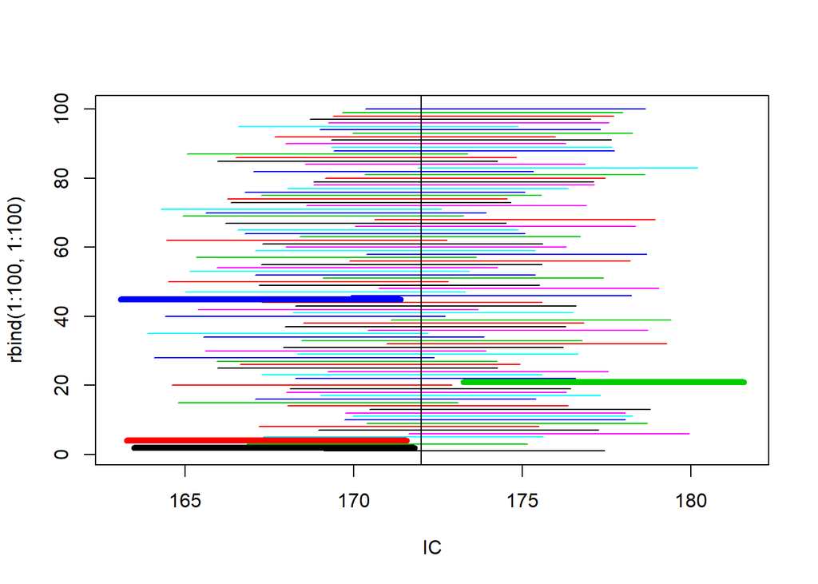

```r
matplot(IC,rbind(1:100,1:100),type="l",lty=1)
abline(v=mu)
out=which(!(IC[1,]<mu & mu<IC[2,]))
matplot(IC[,out],rbind(out,out),type="l",lty=1,add=T,lwd=5)
```

# TAREA

### Instrucciones

- Favor entregar la tarea en un archivo `ZIP` conteniendo tanto el desarrollo en Rmarkdown (archivo .Rmd) como la compilación en HTML.
- Cree una cuenta en www.kaggle.com, un sitio web donde encontrará grandes cantidades de fuentes de datos, así como recursos sobre R, python, y ciencia de datos en general.
- En este ejercicio se utilizará el dataset disponible en https://www.kaggle.com/kmader/colorectal-histology-mnist. Este dataset contiene imágenes histopatológicas de pacientes con cáncer colorrectal. En particular, hay 8 tipos diferentes de tejidos, descritos de forma codificada por la columna `label`. La codificación realizada se muestra en la siguiente tabla:

| Código | Etiqueta |
| --- | --- |
| 1 | TUMOR |
| 2 | STROMA |
| 3 | COMPLEX |
| 4 | LYMPHO |
| 5 | DEBRIS |
| 6 | MUCOSA |
| 7 | ADIPOSE |
| 8 | EMPTY |

Para este ejercicio utilizaremos sólo el dataset que contiene 5000 imágenes de escala de grises de 64 píxeles. Específicamente, baje sólo el archivo $hmnist\_28\_28\_L.csv$ (que pesa 4342 KB comprimido en ZIP). No es necesario bajar todo el dataset completo (que pesa 991MB). Cada fila corresponde a una imagen, mientras que cada columna corresponde al valor de un píxel. Considere que cada imagen se ha desdoblado por columnas (es decir, en cada fila se ha puesto en serie la primera columna, luego la segunda columna y así sucesivamente). Realice todos sus cálculos en el lenguaje `R`.

### Ejercicios

1. Realice un análisis descriptivo (usando también gráficas descriptivas como histogramas, boxplots, etc.) del valor del píxel central de la imagen. Considere los siguientes subconjuntos de datos.
   1. Todas los tipos de tejidos.
   2. Los tejidos con cáncer (TUMOR).
   3. Los tejidos sin cáncer (que no son TUMOR).
   4. Cada uno de los restantes tipos de tejido (STROMA, COMPLEX, etc.).
2. Grafique una imagen de cada tipo en R, a partir del dataset estudiado.
3. Calcule un intervalo de confianza (95% de confianza) para la media de la variable del píxel central para los siguientes casos. Para este cálculo no utilice librerías adicionales, evalúe cada elemento del intervalo usando las funciones disponibles en la distribución estándar de R. En particular, considere las funciones `qt` y `qnorm` para el cálculo de cuantiles.
   1. Los tejidos con cáncer.
   2. Los tejidos sin cáncer.
   3. Cada uno de los restantes tipos de tejido.
4. Repita el punto anterior con las siguientes indicaciones:
   1. Con una muestra aleatoria de 200 imágenes.
   2. Con una muestra aleatoria de 20 imágenes.
   3. Con 100 muestras aleatorias cada una con un tamaño de 200 imágenes. Grafique el histograma de las medias y los intervalos de confianza para cada muestra.
   4. Con 100 muestras aleatorias cada una con un tamaño de 20 imágenes. Grafique el histograma de las medias y los intervalos de confianza para cada muestra.
5. Vuelva y realice todo el análisis de los puntos anteriores pero utilizando como variable, la media de los valores de píxel de cada imagen.